# Northern Goshawk Analysis for the Kispiox Timber Supply Review

Tyler Muhly, Forest Analysis and Inventory Branch

01/03/2022

## Background

Northern goshawk are a medium-sized raptor that live year-round in the Skeena region. They live in mature and old (>80 year old) forest stands, where they prey on small mammals and birds (*Eamer, J. 2018. Action plan for recovery and conservation of interior northern goshawks in the Skeena Region: Background and framework. Prepared for Ministry of Forests, Lands, Natural Resource Operations and Rural Development, Skeena Region. Smithers BC.*). They are territorial and have a high fidelity to nest sites, and thus a breeding pair will use the same breeding and foraging areas year-after-year (*Mahon 2009. Northern Goshawks in West-Central British Columbia 10-Year Project Summary. WildFor Consultants Ltd*). However, a pair does not typically breed every year, and thus multi-year monitoring is needed to assess breeding status (*Mahon, T. 2010. B.C. Ministry of Forests, Mines and Lands. 2010. Evaluating the effectiveness of wildlife habitat areas for Northern Goshawks (Accipiter gentilis laingi) in coastal British Columbia: selection of indicators. B.C. Min. For. Mines Lands,For. Prac. Invest. Br., Victoria, B.C. FREP.*)

There are two subspecies of northern goshawk in British Columbia, the interior subspecies (*Accipiter gentilis atricapillus*) and the coastal subspecies (*Accipiter gentilis laingi*). Both subspecies could occur within the Kispiox TSA, however, the range of the interior subspecies overlaps the majority of the Kispiox TSA, and a ‘transition zone’ where both subspecies’ ranges overlap, covers the southwest portion of the TSA.

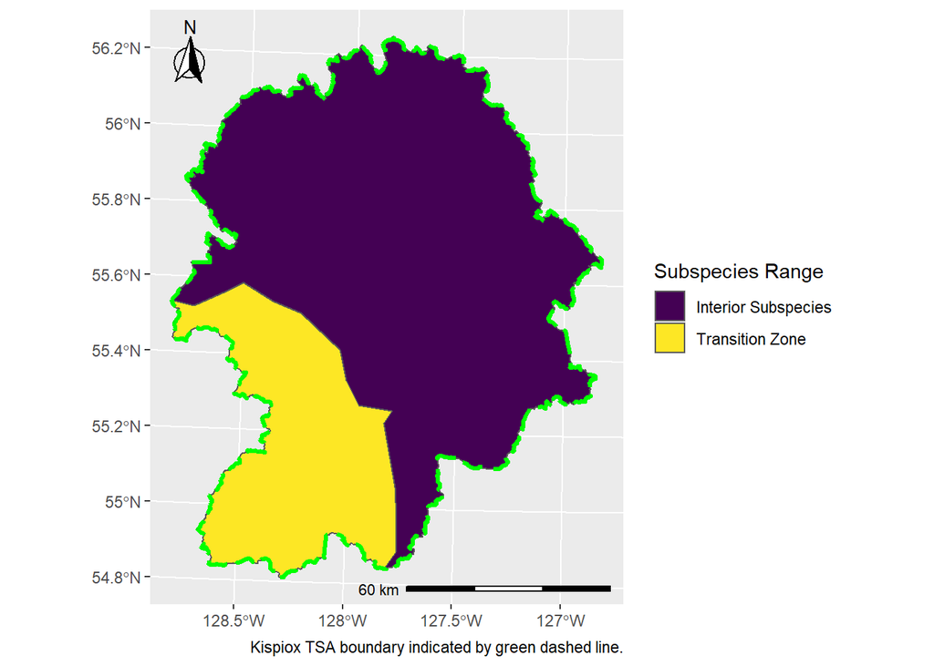

Figure 1. Northern Goshawk Range Overlap with the Kipsiox Timber Supply Area.

### Importance to the Canadian Government

The interior northern goshawk subspecies was assessed in 1995 as *[Not at Risk](https://species-registry.canada.ca/index-en.html#/species/373-0)* by the Committee on the Status of Endangered Wildlife in Canada (COSEWIC). They are not currently listed under the *Species at Risk Act* (SARA).

The coastal subspecies was assessed in 2013 as *[Threatened](https://species-registry.canada.ca/index-en.html#/species/56-45)* by COSEWIC, and listed as [*Threatened* (i.e., likely to become endangered if nothing is done to reverse the factors leading to their extirpation or extinction)](https://wildlife-species.canada.ca/species-risk-registry/species/speciesDetails_e.cfm?sid=56) under SARA.

### Importance to the British Columbian Government

In British Columbia, interior northern goshawk are [*blue listed*](https://www2.gov.bc.ca/gov/content/environment/plants-animals-ecosystems/conservation-data-centre/explore-cdc-data/red-blue-yellow-lists), meaning they are at risk, but not extirpated, endangered or threatened. They have an [S3S4](https://www2.gov.bc.ca/gov/content/environment/plants-animals-ecosystems/conservation-data-centre/explore-cdc-data/status-ranks) conservation status, meaning they are somewhere between ‘apparently secure’ and ‘vulnerable due to a restricted range, relatively few populations, recent and widespread declines, or other factors’.

The coastal subspecies are [*red listed*](https://www2.gov.bc.ca/gov/content/environment/plants-animals-ecosystems/conservation-data-centre/explore-cdc-data/red-blue-yellow-lists), i.e., candidates for extirpated, endangered or threatened status in British Columbia. They have an [S2](https://www2.gov.bc.ca/gov/content/environment/plants-animals-ecosystems/conservation-data-centre/explore-cdc-data/status-ranks) conservation status, meaning they are ‘imperiled’.

Within the Skeena region specifically, recent significant population declines precipitated the development of a “Northern Goshawk (*Accipiter gentilis ssp. atricapillus*) Management Strategy for the Skeena Region” (*Doyle et al. 2017. British Columbia Ministry Forests, Lands, and Natural Resource Operations. Smithers, BC. Pp 1-36*), which included a goal of achieving a minimum of 100 intact territories per timber supply area (TSA). In addition, an “Action Plan for Recovery and Conservation” was developed in 2018, which included immediate actions to halt the decline and prevent the species from becoming endangered or extirpated from the area (Eamer 2018). There are currently no legal protections for interior subspecies of northern goshawk in the Skeena region, but work is ongoing to list them as “regionally important wildlife” to allow for implementation of government action regulation (GAR) protections.

### Importance to First Nations Governments

First Nations in the region have expressed concern with declining northern goshawk populations, and interest in their conservation. However, northern goshawk are not as high priority as other wildlife values, such as moose and grizzly bear.

## Relationship to Forestry

Mature and old coniferous forest that provides closed canopies and open understory is key habitat for northern goshawk (Eamer 2018). Therefore, forest harvest can potentially be a threat to goshawk habitat, and goshawk populations are sensitive to the rate of forest harvest in a region. Mountain pine beetle outbreaks also likely significantly contribute to habitat loss, by killing large conifer trees, reducing canopy closure (*Doyle 2014. Post Mountain Pine Beetle the Status of Northern Goshawk Breeding Areas in the Nadina Resource District. Wildlife Dynamics Consulting.*).

While northern goshawk are sensitive to forestry, they can contribute positively to forest regeneration. In some areas northern goshawk likely limit the abundance of small mammal populations that forage on and damage tree seedlings (*Doyle 2015. Occupancy and Status of Northern Goshawk Breeding Areas in the Coast Mountains (Kalum), Nadina and Skeena Stikine Resource Districts. Wildlife Dynamics Consulting.*).

## Current Conditions

Below summarizes some information on current population and habitat conditions for northern goshawk in the Skeena region and Kispiox TSA.

### Population Status and Trend

Northern goshawk populations have been in significant decline in the Skeena region over the last 20 years. Throughout the region, between the early 2000’s to late 2010’s, 95% of 151 previously known occupied goshawks territories were later found to be abandoned, and upon revisit surveys, only 19% of these territories had sustained intact habitat (Eamer 2018). From 1998 to 2007, the average annual occupancy of over 20 known nests declined from 72% to 26% (Mahon 2009). In a 2014 survey of 129 previously confirmed breeding areas in the Skeena region, only 17 had active breeding pairs (Doyle at al. 2017). Habitat loss and degradation appear to be the primary causes of these regional population declines (Doyle at al. 2017). There were twelve known territories fully within the Kispiox TSA in 2021. In addition, there were 92 ‘predicted’ territories, determined based on forest inventory, biogeoclimatic ecosystem classification and satellite data.

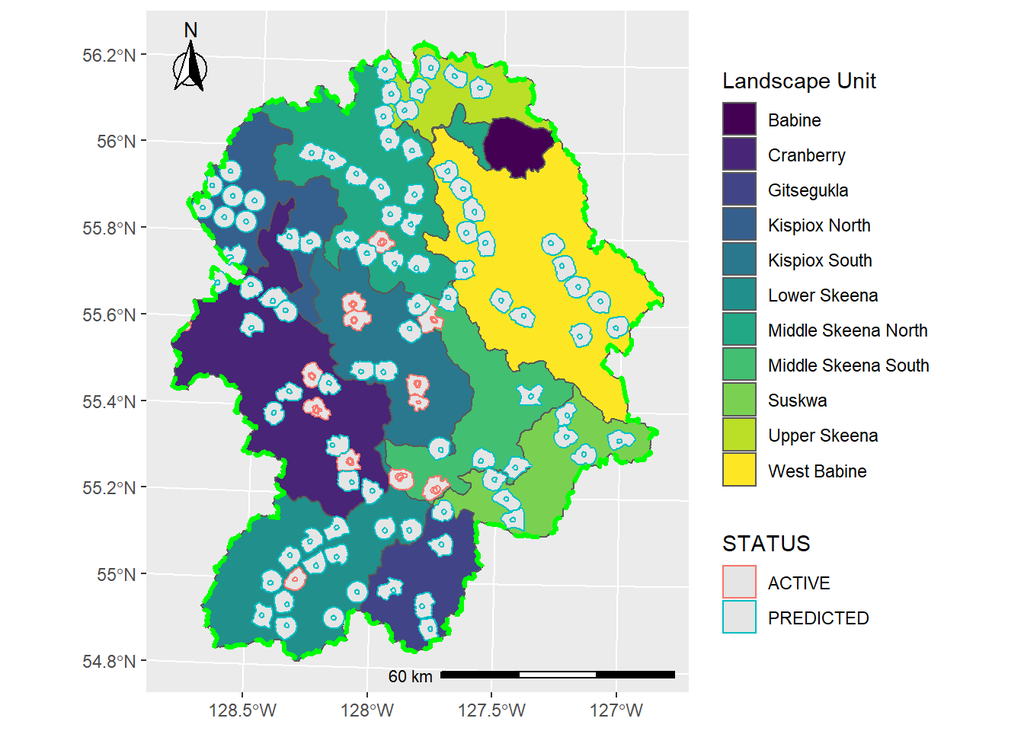

### Forest Stand Characteristics

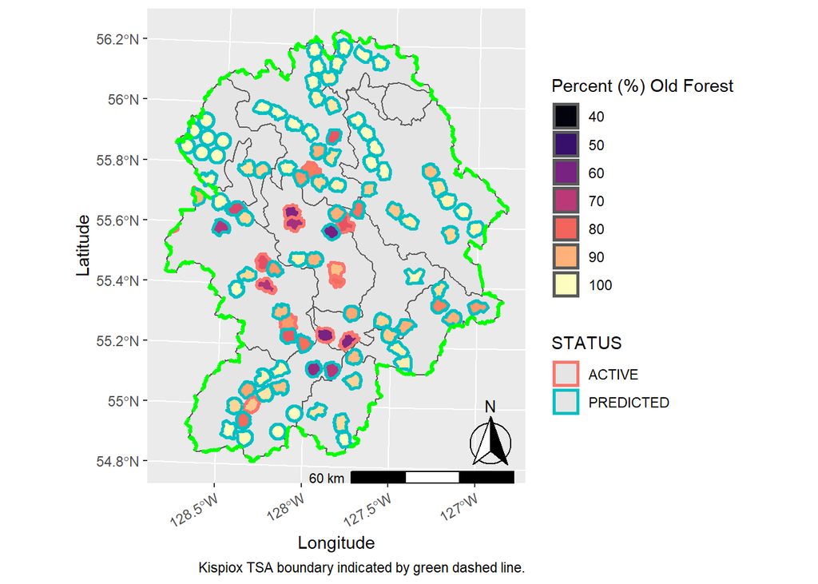

Figure 3. Percent of Mature and Old Forest in Active and Predicted Northern Goshawk Territories Identified in the Kipsiox Timber Supply Area.

## Future Conditions

### Alternate Forest Management Regimes for Northern Goshawk

Recently, a tactical forest planning analysis was completed in the Morice TSA to assess harvest volume under potential habitat management regimes for northern goshawk (Ecora 2021). The analysis divided the TSA into 2,400 ha hexagons to simulate the distribution of northern goshawk territories, and the model used in the analysis required 70% of a simulated territory to have a minimum of 80 year old (mature and old) forest, with no harvest in a 100 ha subset of the habitat representing a breeding territory.

### Timber Supply

For reference, results of the Morice TSA tactical forest planning analysis found that conserving habitat for northern goshawk resulted in a decline of annual harvest volume between 3% to 6% in the short-term and 1% to 2% in the long term (Ecora 2021). The analysis also indicated that greater than 100 territories could be maintained with >70% mature to old forest in the TSA with no impact on timber supply over the next 20 years.

## Mitigating Potential Impacts of Forest Harvest to Northern Goshawk

Northern goshawk are currently managed under ‘best management practices’ (BMPs), where recommendations have been made to protect forested areas within 100m of nesting sites. These BMPs do not appear to have successfully sustained northern goshawk populations, as they do not provide protections for large (>2,400 ha) foraging territories (Eamer 2018).

AAC determinations have been recommended as a tool to set aside habitat targets for goshawk territory requirements (Doyle at al. 2017).

## Uncertainties and Limitations

Known goshawk territories shown here may not be currently occupied, as some of the data is up to 5 years old. However, there are likely occupied territories in the Kispiox TSA that have not been detected, and 12 territories is likely not a viable minimum population size, therefore maintaining habitat conditions outside of these territories (e.g., in predicted territory areas) will be critical to their conservation.

Northern goshawk declines also seem to be related to earlier springs and subsequent hatching of blackflies and blowflies that attack featherless, vulnerable northern goshawk hatchlings (Eamer 2018). Intact habitat is a critical pre-requisite to conserving and maintaining northern goshawk populations, but insects may be an increasingly important limiting factor to populations.